# Words have meaning: initial descriptive language choice and startup success

Zachary Hayes, Justin Liu, Mike McCormick

2022-04-18

## **Data**

### Y Combinator startup company descriptions

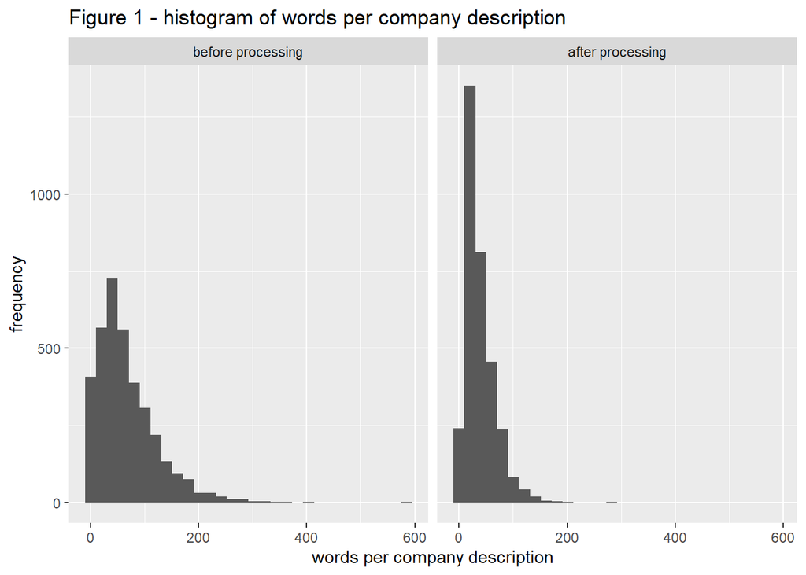

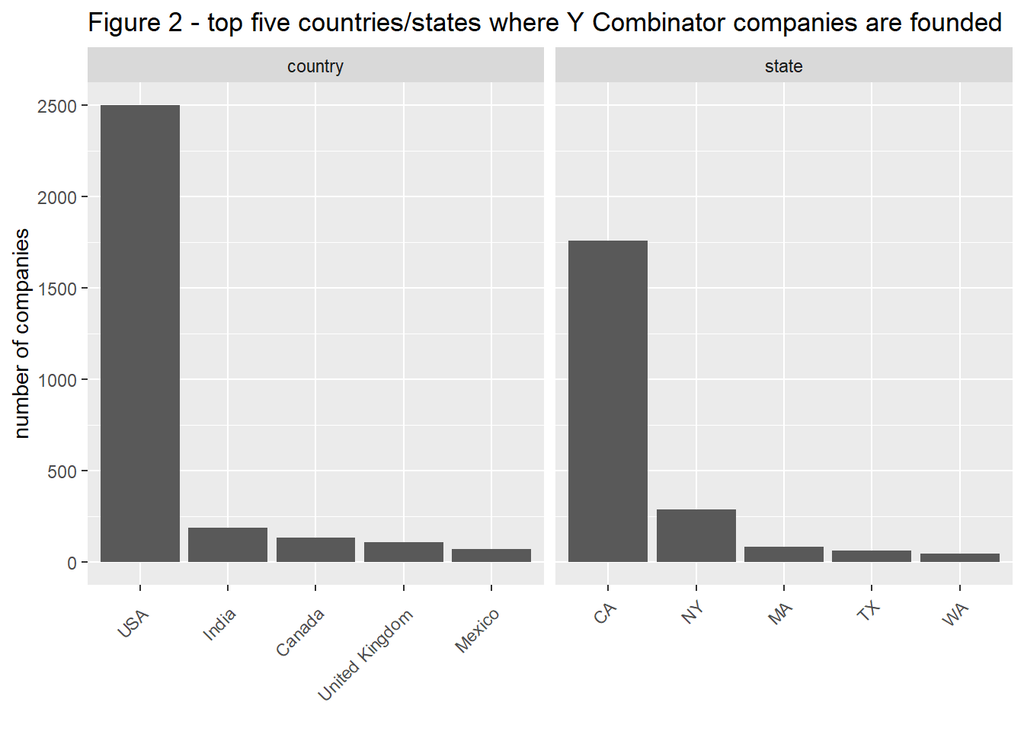

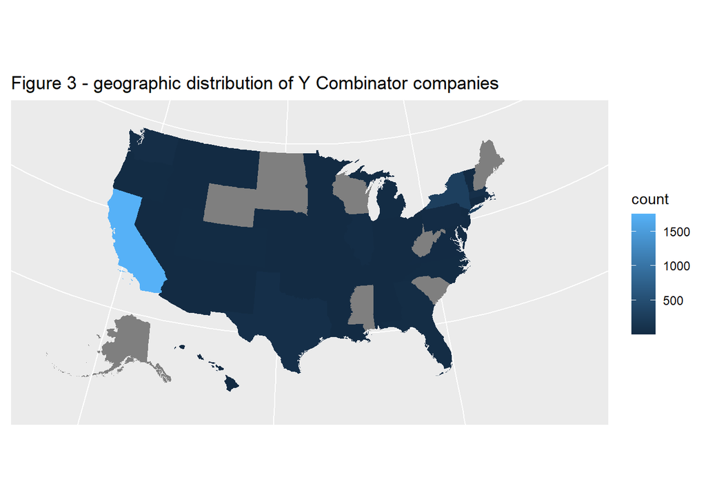

### Open source textbook extracts

**Table 1 - textual data summary statistics**

| data | document count | words per document minimum | words per document lower quartile | words per document mean | words per document median | words per document upper quartile | words per document maximum | words per document standard deviation |
| --- | --- | --- | --- | --- | --- | --- | --- | --- |
| companies, pre-processing | 3586 | 1 | 28 | 66.45901 | 53 | 93 | 586 | 55.06245 |
| companies, post-processing | 3251 | 1 | 19 | 38.47155 | 31 | 52 | 287 | 27.17250 |
| textbooks, pre-processing | 5 | 344 | 2039 | 3009.60000 | 2841 | 3583 | 6241 | 2170.63627 |
| textbooks, post-processing | 5 | 181 | 1067 | 1676.80000 | 1918 | 2065 | 3153 | 1117.73396 |

### Crunchbase startup funding data

**Table 2 - funding and exit data for Y Combinator companies**

| status | count |
| --- | --- |
| total | 3251 |
| active | 2386 |
| funded | 1153 |
| inactive | 488 |
| acquired | 362 |
| public | 15 |

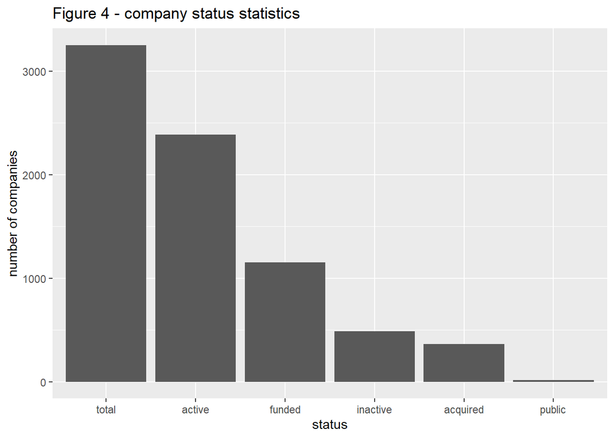

## **Methodology and results**

### **Methodology**

Once we obtained the required data, our methodology followed three main steps: (1) processing the data into useable form, (2) calculating cosine and Jaccard similarity scores between each company description and each textbook, and (3) use ordered and multivariate regressions to analyse the relationship between the calculated similarity scores and company outcomes. These steps are discussed in detail in the following sections.

#### Data processing

##### Textual data

Our two separate sources of textual data required different means to extract and then process into usable formats. We extracted the company descriptions using the rvest package, looping through each company’s individual website and scraping the required information. For the five textbooks, we manually extracted just the table of contents, index, or glossary (as available, it varied per textbook) and then imported them into R using the pdftools package.

The initial textual data, once imported into R, was still not in a format useful for analysis. We followed several steps to convert the data into a usable format:

1. We removed all numbers, whitespace, punctuation, and any blank or “NA” rows to reduce the data to just words.
2. Next, we “lemmatized” each word using the textstem::lemmatize_words function. This function uses a dictionary based on the Mechura 2016 English lemmatization list. This step reduced the words to common base forms, reducing the complexity of the data and making it easier to analyze.
3. Finally, we calculated term frequencies for each document, and then used this information to build a document-term matrix of all the company descriptions, textbook extracts, and terms. The matrix contains a set of vectors for each textbook extract and company description, with each value corresponding to a specific term and the frequency it is found in each document.

##### Funding and exit data

We based the current status of each company based on information scraped from the Y Combinator website - each company is described as either “Inactive” (gone out of business), “Active”, “Acquired”, or “Public”. We were fortunate in this project in that the Y Combinator and Crunchbase websites use a similar naming convention for companies, making joining the textual data with the funding data an easy step. We filtered the Crunchbase funding data down to the company name and the number of funding rounds received and joined this data to the list of companies using the dplyr::left_join function. The Crunchbase data only included companies that have received startup funding, enabling us to define a second logical variable for whether or not a company had received funding.

#### Similarity scores

The final processing step required was to calculate the similarity between each company description and the textbook extracts, i.e. how similar a company’s initial descriptive language is to a business topic. We did this using two measures, the cosine and Jaccard similarity scores between each company description and each textbook.

We calculated the cosine similarity score for each company description using the lsa::cosine function. This function takes two arguments, the respective vectors for each company description and textbook, and returns a cosine similarity score. In mathematical terms, this score is the dot product of the two vectors divided by the product of their lengths.

The Jaccard similarity score is similar to the cosine similarity score, but only considers unique words per document instead of frequency. To calculate this score, we first converted each vector into a logical vector, based on whether or not the term was present in the respective document. The Jaccard similarity score is then calculated as the intersection of the two vectors divided by the union of the two vectors.

The mean cosine and Jaccard similarity scores for each company, grouped by company status, are listed in the below table.

**Table 3 - similarity scores by company status**

| status | count | Mean cosine similarity scores entrepreneurship | Mean cosine similarity scores finance | Mean cosine similarity scores leadership | Mean cosine similarity scores marketing | Mean cosine similarity scores strategy |
| --- | --- | --- | --- | --- | --- | --- |
| Acquired | 362 | 0.0738666 | 0.0255525 | 0.0403263 | 0.0272614 | 0.0498762 |
| Active | 2386 | 0.0784647 | 0.0298825 | 0.0418272 | 0.0335066 | 0.0526428 |
| Inactive | 488 | 0.0651645 | 0.0222868 | 0.0358728 | 0.0272202 | 0.0461308 |
| Public | 15 | 0.1074728 | 0.0321027 | 0.0614199 | 0.0352015 | 0.0725202 |

| status | count | Mean Jaccard similarity scores entrepreneurship | Mean Jaccard similarity scores finance | Mean Jaccard similarity scores leadership | Mean Jaccard similarity scores marketing | Mean Jaccard similarity scores strategy |
| --- | --- | --- | --- | --- | --- | --- |
| Acquired | 362 | 0.0004728 | 0.0002122 | 0.0002551 | 0.0000659 | 0.0002961 |
| Active | 2386 | 0.0004464 | 0.0002053 | 0.0002590 | 0.0000649 | 0.0002824 |
| Inactive | 488 | 0.0003831 | 0.0001778 | 0.0002160 | 0.0000570 | 0.0002429 |
| Public | 15 | 0.0006702 | 0.0002840 | 0.0004078 | 0.0001092 | 0.0004442 |

### **Results**

**Table 4 - exit status regression table**

| term | estimate | log odds | std.error | t statistic | p value | coef.type |
| --- | --- | --- | --- | --- | --- | --- |
| ent_c | 1.4308724 | 4.182347e+00 | 1.3944003 | 1.026156e+00 | 0.3048180 | coefficient |
| fin_c | -0.5290431 | 5.891685e-01 | 1.4805517 | -3.573283e-01 | 0.7208460 | coefficient |
| ldr_c | 3.1763422 | 2.395896e+01 | 1.5903768 | 1.997226e+00 | 0.0458006 | coefficient |
| mkt_c | -1.2159323 | 2.964335e-01 | 0.8584770 | -1.416383e+00 | 0.1566634 | coefficient |
| str_c | -3.2406770 | 3.913740e-02 | 1.9529217 | -1.659399e+00 | 0.0970354 | coefficient |
| ent_j | 1267.7589882 | Inf | 0.0037398 | 3.389887e+05 | 0.0000000 | coefficient |
| fin_j | 419.0829791 | 1.012571e+182 | 0.0030495 | 1.374271e+05 | 0.0000000 | coefficient |
| ldr_j | -2442.6144174 | 0.000000e+00 | 0.0041386 | -5.902061e+05 | 0.0000000 | coefficient |
| mkt_j | 745.5850996 | Inf | 0.0013264 | 5.621172e+05 | 0.0000000 | coefficient |
| str_j | 1078.0305844 | Inf | 0.0043240 | 2.493123e+05 | 0.0000000 | coefficient |
| Inactive\|Active | -1.3724071 | 2.534960e-01 | 0.0779986 | -1.759528e+01 | 0.0000000 | scale |
| Active\|Acquired | 2.4571785 | 1.167183e+01 | 0.0868109 | 2.830496e+01 | 0.0000000 | scale |
| Acquired\|Public | 5.8110501 | 3.339696e+02 | 0.2673527 | 2.173552e+01 | 0.0000000 | scale |

**Table 5 - funded regression table**

| term | estimate | std.error | statistic | p.value |
| --- | --- | --- | --- | --- |
| (Intercept) | -0.6021217 | 0.075806 | -7.9429338 | 0.0000000 |
| ent_c | -3.1122222 | 1.462765 | -2.1276304 | 0.0333677 |
| fin_c | -7.7819262 | 1.848884 | -4.2089853 | 0.0000257 |
| ldr_c | 1.7989371 | 1.750830 | 1.0274768 | 0.3041960 |
| mkt_c | -2.6269333 | 1.027653 | -2.5562452 | 0.0105809 |
| str_c | 3.6325517 | 2.087376 | 1.7402482 | 0.0818154 |
| ent_j | 1027.8160713 | 357.883129 | 2.8719322 | 0.0040797 |
| fin_j | -482.8442896 | 541.929932 | -0.8909718 | 0.3729443 |
| ldr_j | -963.1932609 | 500.930394 | -1.9228086 | 0.0545041 |
| mkt_j | -129.7534025 | 1015.312243 | -0.1277966 | 0.8983100 |
| str_j | 590.4033507 | 517.827425 | 1.1401547 | 0.2542219 |

## **References**

### R libraries

We used the below libraries in our analysis and to develop this report:

tidyverse / tm / MASS

xml2 / rvest / urbnmapr

here / dplyr / broom

tidytext / textstem / sjPlot

pdftools / textclean / widyr

text2vec / lsa / kableExtra

### Data sources

#### Company descriptions

All company descriptions were scraped from their respective page at ycombinator.com/companies

#### Textbooks

Entrepeneurship: openstax, Entrepeneurship Finance: Robert C. Higgins, Analysis for Financial Management, 10th Edition Leadership: Richard L. Daft, The Leadership Experience Marketing: Introducing Marketing, Open Textbook Library Strategy: Strategic Management, VA Tech

#### Funding data

Crunchbase funding data provided by Katie Moon, Professor of Finance at University of Colorado Boulder.